# Basics of MCMC simulation

Pablo Perez

18/10/2020

## Simulating normally distributed data

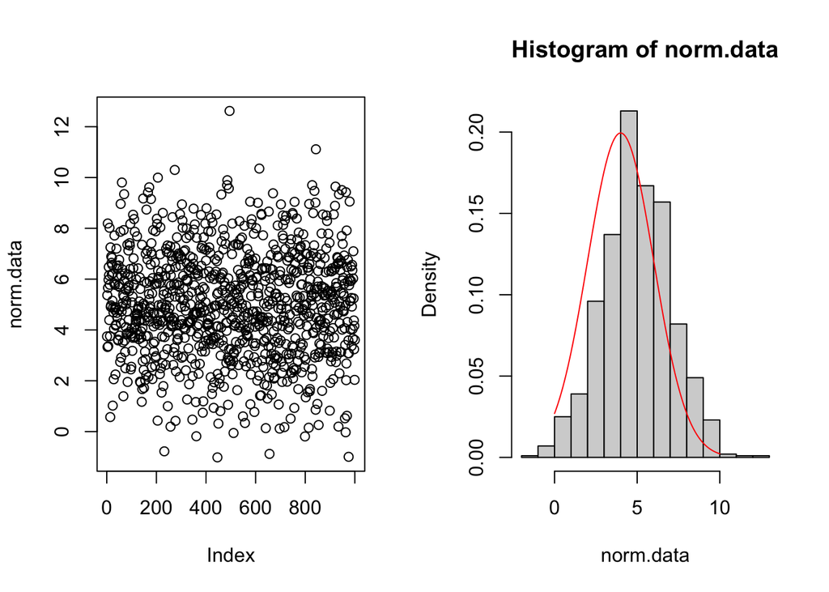

```r
norm.data <- rnorm(n=1000,mean=5,sd=2)
par(mfrow=c(1,2))
plot(norm.data)
hist(norm.data,freq=F)
curve(dnorm(x,mean=4,sd=2),from=0,to=10,add=T,col="red")
```

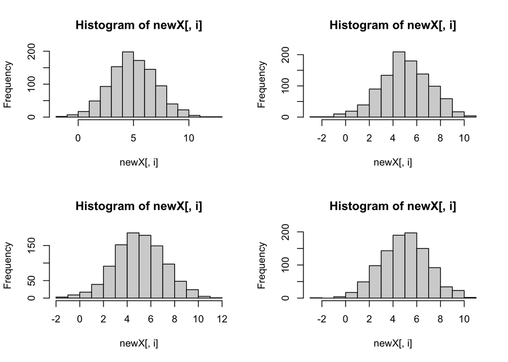

```
#> [[1]]
#> $breaks
#>  [1] -2 -1  0  1  2  3  4  5  6  7  8  9 10 11 12 13
#>
#> $counts
#>  [1]   2   7  17  49  93 153 198 172 145  95  40  22   5   1   1
#>
#> $density
#>  [1] 0.002 0.007 0.017 0.049 0.093 0.153 0.198 0.172 0.145 0.095 0.040 0.022
#> [13] 0.005 0.001 0.001
#>
#> $mids
#>  [1] -1.5 -0.5  0.5  1.5  2.5  3.5  4.5  5.5  6.5  7.5  8.5  9.5 10.5 11.5 12.5
#>
#> $xname
#> [1] "newX[, i]"
#>
#> $equidist
#> [1] TRUE
#>
#> attr(,"class")
#> [1] "histogram"
#>
#> [[2]]
#> $breaks
#>  [1] -3 -2 -1  0  1  2  3  4  5  6  7  8  9 10 11
#>
#> $counts
#>  [1]   1   1  10  19  39  90 134 209 180 138  99  59  17   4
#>
#> $density
#>  [1] 0.001 0.001 0.010 0.019 0.039 0.090 0.134 0.209 0.180 0.138 0.099 0.059
#> [13] 0.017 0.004
#>
#> $mids
#>  [1] -2.5 -1.5 -0.5  0.5  1.5  2.5  3.5  4.5  5.5  6.5  7.5  8.5  9.5 10.5
#>
#> $xname
#> [1] "newX[, i]"
#>
```

[output cut: 44 more lines]

```
#> [1] "newX[, i]"
#>
#> $equidist
#> [1] TRUE
#>
#> attr(,"class")
#> [1] "histogram"
apply(X = norm.data.2, MARGIN = 2, FUN = mean)
#> [1] 4.967476 5.030618 5.033444 4.959873
apply(X = norm.data.2, MARGIN = 2, FUN = sd)
#> [1] 2.079963 2.062214 2.077307 1.978743
sd(apply(X = norm.data.2, MARGIN = 2, FUN = mean))
#> [1] 0.03960446
2/sqrt(1000)
#> [1] 0.06324555
```

```r
norm.data.2 <- replicate(n=4, rnorm(n=1000, mean=5, sd=2))
par(mfrow=c(2,2))
apply(X = norm.data.2, MARGIN = 2, FUN = hist)
```

A `for` loop can be more efficient when simulating a large number of iterations or large datasets. In this example, 2,000 iterations of normally distributed datasets are created. The histogram shows the spread of the means.

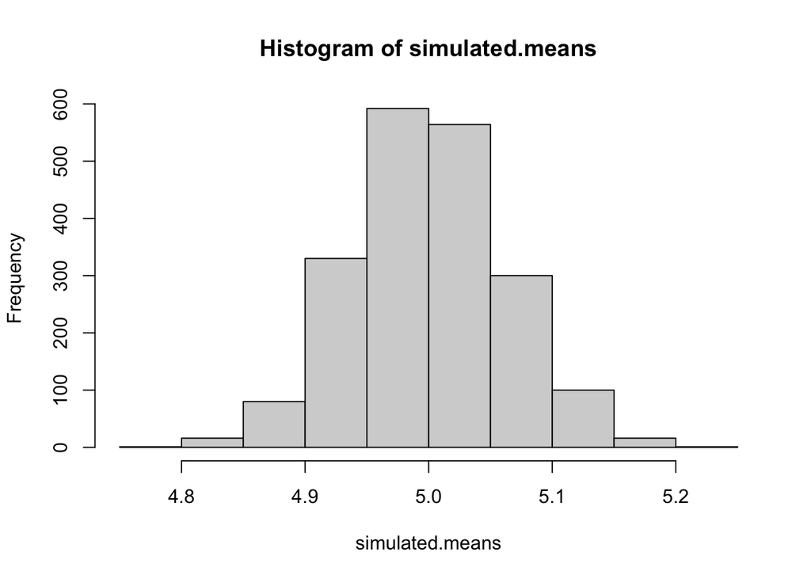

```r
N = 2000
simulated.means <- rep(NA, N)

for (i in 1:N) {
  sim.dat <- rnorm(n=1000, mean=5, sd=2)
  simulated.means[i] <- mean(sim.dat)
  rm(sim.dat)
}

hist(simulated.means)
```

```r
sd(simulated.means)
```

```
#> [1] 0.06250561
```

## Simulating a numeric variable (linear regression)

This next example models a dataset from the intercept and slope of a theoretical (`y_fixex`) regression line of the form `a + b*x`.

```r
a <- 5
b <- 0.7
x <- seq(2,20)
y_fixed <- a + b*x

# Fixed relation
par(mfrow=c(2,1))
plot(y_fixed~x,)

# Simulation (sd incorporates random variation)
y.sim.1 <- rnorm(length(x), mean=y_fixed, sd=2.5)
plot(y.sim.1~x)
abline(a=a, b=b, lwd=2)

# Linear regression
y.lm <- lm(y.sim.1~x)
summary(y.lm)
```

```
#>
#> Call:
#> lm(formula = y.sim.1 ~ x)
#>
#> Residuals:
#>     Min      1Q  Median      3Q     Max
#> -4.6098 -1.3376  0.6271  1.7149  3.7500
#>
#> Coefficients:
#>             Estimate Std. Error t value Pr(>|t|)
#> (Intercept)   5.2725     1.2662   4.164  0.00065 ***
#> x             0.6697     0.1030   6.499 5.45e-06 ***
#> ---
#> Signif. codes:  0 '***' 0.001 '**' 0.01 '*' 0.05 '.' 0.1 ' ' 1
#>
#> Residual standard error: 2.46 on 17 degrees of freedom
#> Multiple R-squared:  0.713,  Adjusted R-squared:  0.6961
#> F-statistic: 42.24 on 1 and 17 DF,  p-value: 5.453e-06
```

```r
confint(y.lm)
```

```
#>                 2.5 %    97.5 %
#> (Intercept) 2.6009697 7.9439616
#> x           0.4522923 0.8870988
```

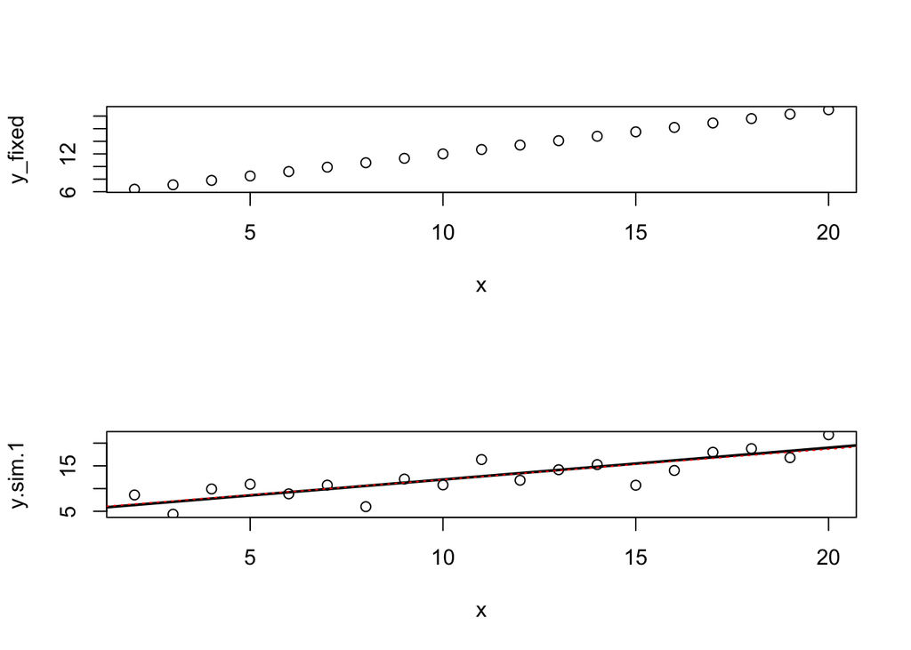

```r
abline(reg=y.lm, lty=3, col="red")
```

## Excercise 1

Write a for loop that does the above simulation 200 times and plot the regression line for each (use type=“n” to supress the points)

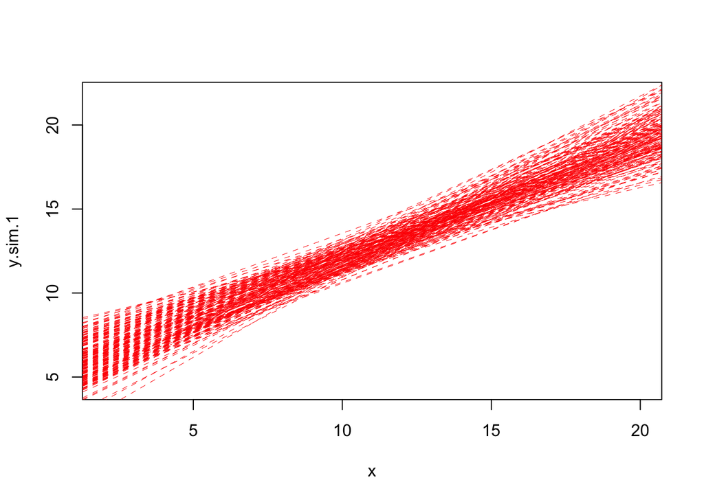

```r
N <- 200
plot(y.sim.1~x,type="n")
for (i in 1:N) {
  sim.dat <- rnorm(length(x), mean=y_fixed, sd=2.5)
  sim.lm <- lm(sim.dat~x)
  abline(reg=sim.lm, lty=2, lwd=0.5, col="red")
  rm(sim.dat,sim.lm)
}
```

## Generating confidence intervals

This example simulates data of known response and co-variate variable values.

```r
x <- -10:10 # co-variate
b0 <- 0
b1 <- 1.5 # slope

# vector of 'observed' values for the response variable
y.sim <- rnorm(length(x), b0 + b1*x, 10)

plot(y.sim~x)
lm.y <- lm(y.sim~x)
coef(lm.y)
```

```
#> (Intercept)           x
#>   -2.219851    1.075388
```

```r
confint(lm.y)
```

```
#>                  2.5 %   97.5 %
#> (Intercept) -5.7296749 1.289974
#> x            0.4957592 1.655016
```

```r
vcov(lm.y)
```

```
#>             (Intercept)          x
#> (Intercept)    2.812045 0.00000000
#> x              0.000000 0.07669214
```

```r
summary(lm.y)
```

```
#>
#> Call:
#> lm(formula = y.sim ~ x)
#>
#> Residuals:
#>      Min       1Q   Median       3Q      Max
#> -15.2926  -3.9011   0.6157   4.9948  13.4432
#>
#> Coefficients:
#>             Estimate Std. Error t value Pr(>|t|)
#> (Intercept)  -2.2199     1.6769  -1.324    0.201
#> x             1.0754     0.2769   3.883    0.001 **
#> ---
#> Signif. codes:  0 '***' 0.001 '**' 0.01 '*' 0.05 '.' 0.1 ' ' 1
#>
#> Residual standard error: 7.685 on 19 degrees of freedom
#> Multiple R-squared:  0.4425, Adjusted R-squared:  0.4131
#> F-statistic: 15.08 on 1 and 19 DF,  p-value: 0.001
```

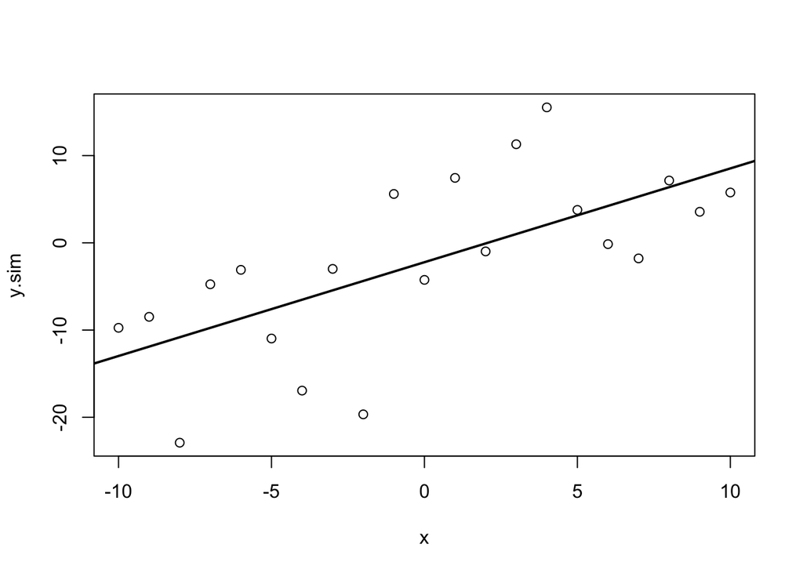

```r
abline(lm.y,lwd=2)
```

The asymptotic normal confidence intervals are what would be constructed based on the SE and t-distribution. For an observed dataset, this can be calculated using the `predict` function.

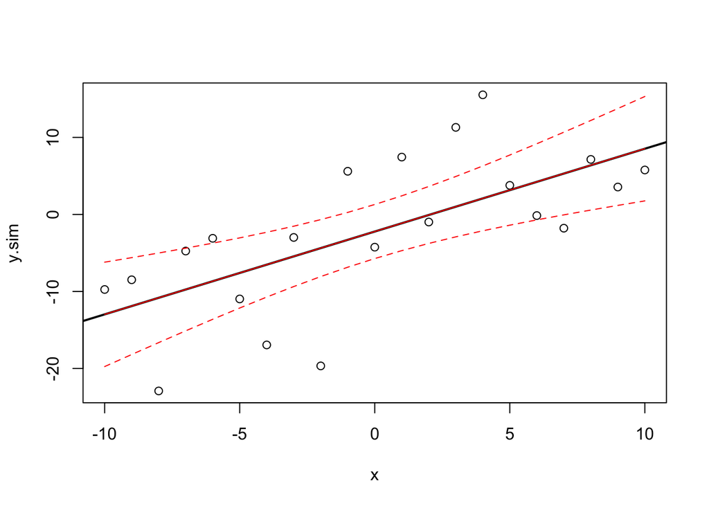

```r
x.frame <- data.frame(x=x)

conf.int <- predict(lm.y, interval="conf", newdata = x.frame)

plot(y.sim~x)
abline(lm.y,lwd=2)
matlines(x=x.frame$x, y = conf.int, lty = c(1,2,2), col="red")
```

## Monte Carlo simulation

The following function will run an MC simulation, not accounting for uncertainty around residual variation. It simulates a linear model with intercept `a`, slope `b` and standard deviation `rse`. It then performs linear regression and extracts confidence co-efficients. The confidence intervals will be narrow. *Why?*.

```r
SimReg1 <- function(mod.input = lm.y) {
  a = coef(mod.input)[1]
  b = coef(mod.input)[2]
  rse = summary(mod.input)$sigma

  y <- rnorm(n = length(x), mean = a + b*x, sd = rse) # simulated responses
  lm.sim <- lm(y~x) # fitted model
  coef(lm.sim)
}

N <- 1000 # number of simulations
simulated.coef <- replicate(N, SimReg1()) # run the simulation

simulated.coef <- t(simulated.coef) # transpose output for convenience

sd(simulated.coef[,1]) # this should approximate the SE for the intercept
```

```
#> [1] 1.615461
```

```r
sd(simulated.coef[,2]) # this should approximate the SE for the slope
```

```
#> [1] 0.2864687
```

```r
# compare to
summary(lm.y)$coef[,1:2]
```

```
#>              Estimate Std. Error
#> (Intercept) -2.219851  1.6769154
#> x            1.075388  0.2769335
```

```r
# MC confidence intervals for the slope
quantile(simulated.coef[,2], c(0.025,0.975))
```

```
#>      2.5%     97.5%
#> 0.4891713 1.6136565
```

```r
# compare to
confint(lm.y)[2,]
```

```
#>     2.5 %    97.5 %
#> 0.4957592 1.6550160
```

```r
# check for correlation between the estimates (slopes and intercepts)
cor(simulated.coef[,1], simulated.coef[,2])
```

```
#> [1] -0.00968973
```

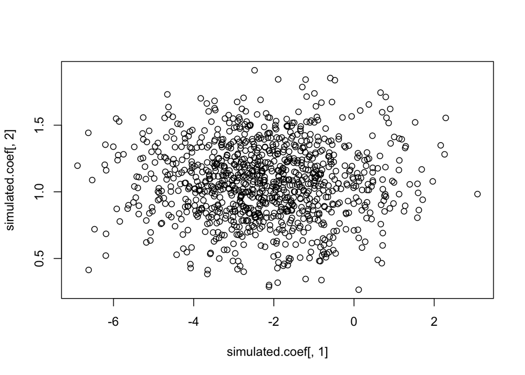

```r
plot(simulated.coef[,1],simulated.coef[,2])
```

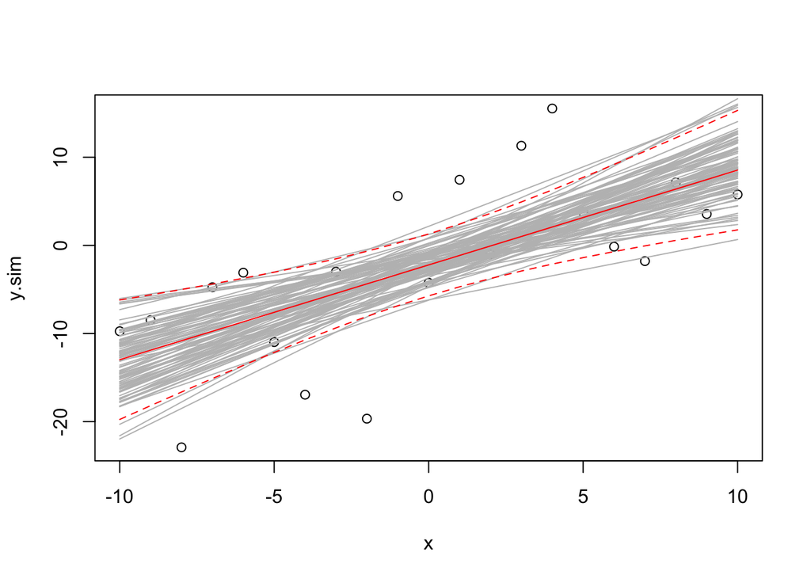

```r
# Plot of confidence bands asymptotic vs MC

plot(y.sim~x) # scatter plot

for (i in 1:95) { # first 95 values from MC simulation
  curve(simulated.coef[i,1] + simulated.coef[i,2] * x, add=T, col="grey")
}
matlines(x=x.frame$x, y = conf.int, lty = c(1,2,2), col="red") # asymptotic normal CIs
```

## Accounting for uncertainty in RSE

The above CIs generaterd by the MC simulation are narrow, as they do not account for uncertainty on RSE. The following simulation corrects for this, as RSE represents a *random* sample from another distribution. This correction thus propagates error by sampling from RSE and then sampling values conditional on that.

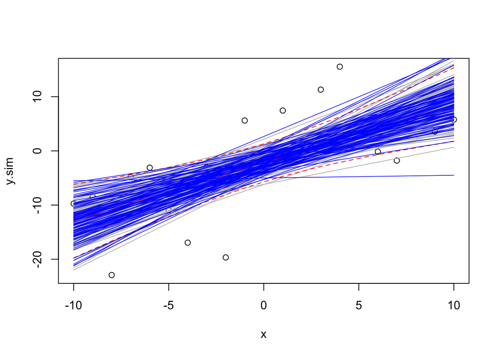

```r
SimReg2 <- function(mod.input = lm.y) {
  a = coef(mod.input)[1]
  b = coef(mod.input)[2]
  df.sim <- mod.input$df
  rse = summary(mod.input)$sigma
  rse.sim <- rse*sqrt(df.sim/rchisq(1, df=df.sim)) # incorporate uncertainty

  y <- rnorm(n = length(x), mean = a + b*x, sd = rse.sim) # simulated responses
  lm.sim <- lm(y~x) # fitted model
  coef(lm.sim)
}

simulated.coef.corrected <- replicate(N, SimReg2()) # run the simulation
simulated.coef.corrected <- t(simulated.coef.corrected) # transpose output for convenience

# Previous plot
plot(y.sim~x) # scatter plot
for (i in 1:95) { # first 95 values from MC simulation
  curve(simulated.coef[i,1] + simulated.coef[i,2] * x, add=T, col="grey")}
matlines(x=x.frame$x, y = conf.int, lty = c(1,2,2), col="red") # asymptotic normal CIs

# Add correction to plot
for (i in 1:95) {
  curve(simulated.coef.corrected[i,1] + simulated.coef.corrected[i,2] * x,
        add=T, col="blue", lwd=0.8)
}
```

```r
# Compare CIs with previous model and simulated data
quantile(simulated.coef.corrected[,2], c(0.025,0.975))
```

```
#>      2.5%     97.5%
#> 0.5054066 1.6798255
```

```r
quantile(simulated.coef[,2], c(0.025,0.975))
```

```
#>      2.5%     97.5%
#> 0.4891713 1.6136565
```

```r
confint(lm.y)[2,]
```

```
#>     2.5 %    97.5 %
#> 0.4957592 1.6550160
```

Note the example above is not yet accounting for co-variation in parameter estimates. The next bit of code uses a `for` loop instead of the `replicate` function to arrive at the same results.

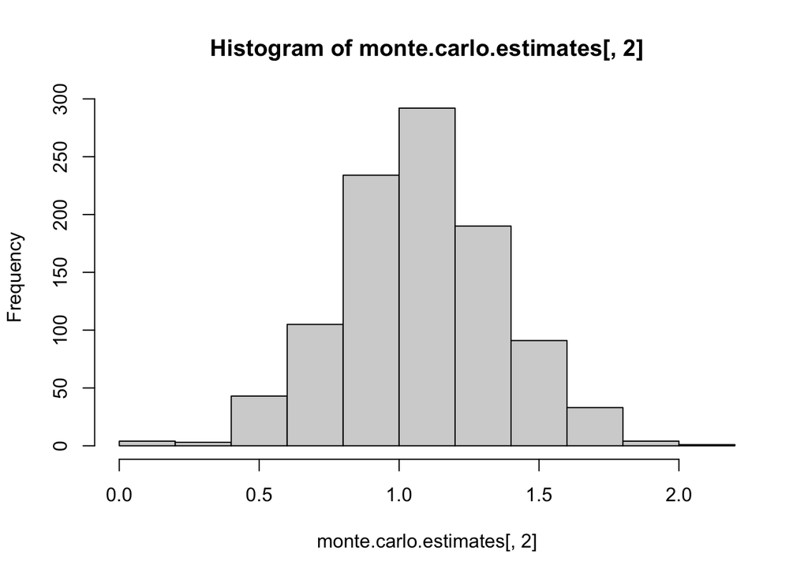

```r
monte.carlo.estimates <- matrix(NA, ncol=2, nrow=N)

for (i in 1:N) {
  monte.carlo.estimates[i,] <- SimReg2()
}

hist(monte.carlo.estimates[,2])

require(arm)
```

```r
model.sim <- sim(lm.y, n.sims=N)
sim.slopes <- model.sim@coef[,2]
quantile(sim.slopes, c(0.025,0.975))
```

```
#>      2.5%     97.5%
#> 0.5024647 1.6886917
```

```r
confint(lm.y)
```

```
#>                  2.5 %   97.5 %
#> (Intercept) -5.7296749 1.289974
#> x            0.4957592 1.655016
```

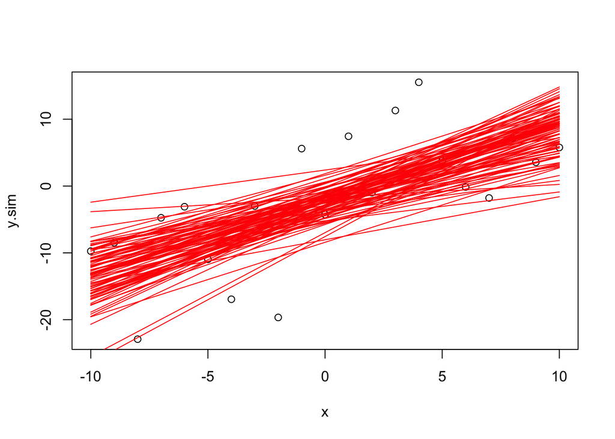

```r
plot(y.sim~x)
for (i in 1:95) {
  curve(model.sim@coef[i,1] + model.sim@coef[i,2] * x, add=T, col="red")
}
```